# Decision Trees

## Marketing Analytics Process

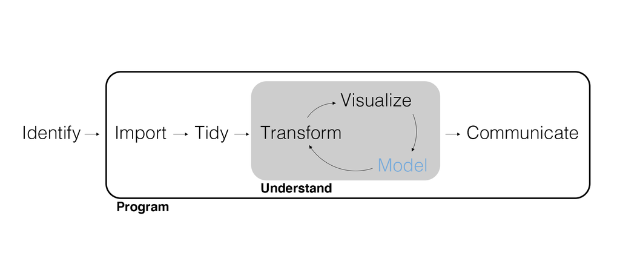

## Predictive Modeling Workflow

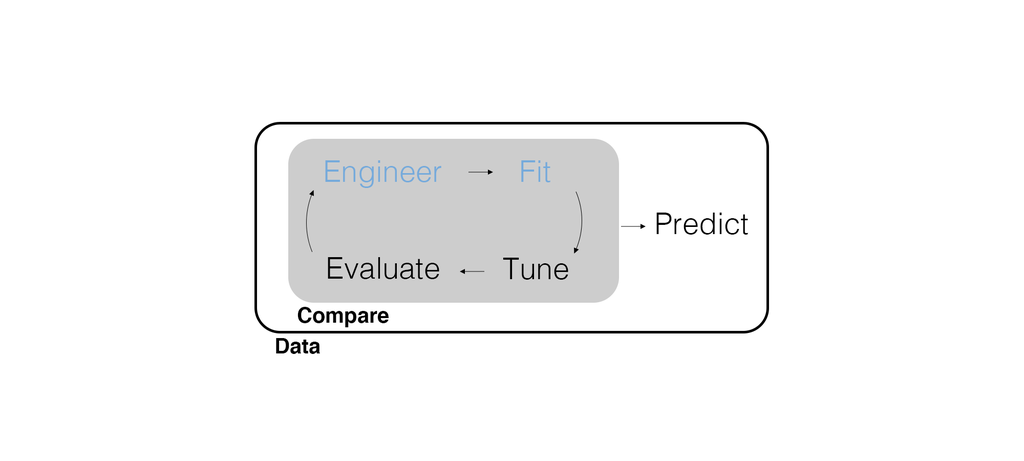

[figure not shown]

## Supervised Learning and Prediction

Today, we will be doing *supervised learning* with the goal of *prediction*. So instead of letting our beliefs and hypotheses about our story drive our selection of variables and worrying about whether our coefficient estimates are accurate, we’ll need to run a *lot* of models and find which one is best for predicting the outcome we care about.

## How Do We know Whether We Care About Inference or Prediction?

- If a model is used to make operational decisions? –> *Prediction*.
- If a model is used to explain behavior or outcomes, or allow us to intervene in a process? –> *Inference*.

What are some examples of prediction-focused use cases?

## Import Data

Let’s import and work with some new data.

```r
# Load packages.
library(tidyverse)
library(tidymodels)
```

In this unit, we’ll be examining survey data from iRobot (Roomba).

```r
roomba_survey <- read_csv("roomba_survey.csv")

roomba_survey
```

```
## # A tibble: 332 × 128
##    sys_RespNum sys_StartTime sys_EndTime sys_LastQuestion sys_CBC_CBC1_design
##          <dbl>         <dbl>       <dbl> <chr>            <chr>
##  1           2    1456893467  1456893958 Finished         [[1,1,1,2,1,2,2,1],[2…
##  2           3    1456893643  1456893998 Finished         [[1,4,2,1,2,1,1,1],[2…
##  3           4    1456893769  1456893998 Finished         [[1,3,2,2,1,2,1,4],[2…
##  4           9    1456895699  1456904874 Finished         [[1,2,2,1,1,1,1,3],[2…
##  5          23    1456924935  1456925731 Finished         [[1,1,1,2,1,2,1,4],[2…
##  6          24    1456930656  1456932188 Finished         [[1,3,2,2,1,1,1,2],[2…
##  7          28    1456943719  1456943970 Finished         [[1,4,2,1,2,1,1,1],[2…
##  8          30    1456945961  1456946585 Finished         [[1,4,1,1,1,1,2,2],[2…
##  9          31    1456946554  1456946910 Finished         [[1,1,2,2,2,1,2,2],[2…
## 10          33    1456946838  1456947219 Finished         [[1,1,1,1,2,1,2,3],[2…
## # ℹ 322 more rows
## # ℹ 123 more variables: sys_CBC_CBC1_design_info <chr>, S1 <dbl>, S1A <dbl>,
## #   S1B <dbl>, S1C <dbl>, S1C_9_other <chr>, S2 <dbl>, S3Age <dbl>,
## #   S4Income <dbl>, CleaningAttitudes_1 <dbl>, CleaningAttitudes_2 <dbl>,
## #   CleaningAttitudes_3 <dbl>, CleaningAttitudes_4 <dbl>,
## #   CleaningAttitudes_5 <dbl>, CleaningAttitudes_6 <dbl>,
## #   CleaningAttitudes_7 <dbl>, CleaningAttitudes_8 <dbl>, …
```

```r
# Answers to S1? This is Q1 in the survey dictionary, i.e., the first screening question.
roomba_survey |>
  count(S1)
```

```
## # A tibble: 3 × 2
##      S1     n
##   <dbl> <int>
## 1     1    40
## 2     3    63
## 3     4   229
```

## Outcome Variable

Going forward, we will perform feature engineering on our **outcome** variable first. In other words, we pre-process our outcome variable first, then split and pre-process our training and testing data.

```r
# Wrangle S1 into segment.
roomba_survey <- roomba_survey |>
  rename(segment = S1) |>
  mutate(
    # easier way to do multiple if-else statements!
    segment = case_when(
      segment == 1 ~ "own",
      segment == 3 ~ "shopping",
      segment == 4 ~ "considering"
    ),
    segment = factor(segment)
  )
```

[figure not shown]

## Data Splitting by Strata

Next, we need to split the data. To be sure that we don’t end up with testing data that doesn’t include one of the categories in our outcome variable, use the `strata` argument.

```r
set.seed(42)

# Split data based on segment.
roomba_split <- initial_split(roomba_survey, prop = 0.75, strata = segment)
```

When using the `strata` argument, the splitting proportion is applied to each stratum separately.

## Decision Trees

We might be tempted to use a logistic regression since this is a classification model, but why wouldn’t it work for this outcome?

Let’s use a **decision tree**.

- Instead of fitting a line, split the data based on a decision rule using one of the predictors.
- Keep adding decision rules based on more predictors to split the data further.
- Use the resulting regions to classify (or minimize the residual sum of squares if its regression).

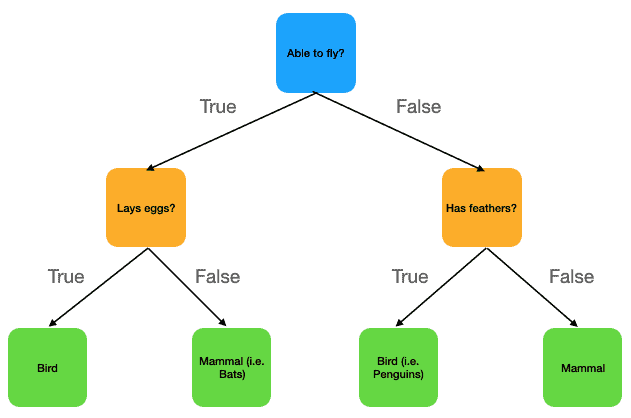

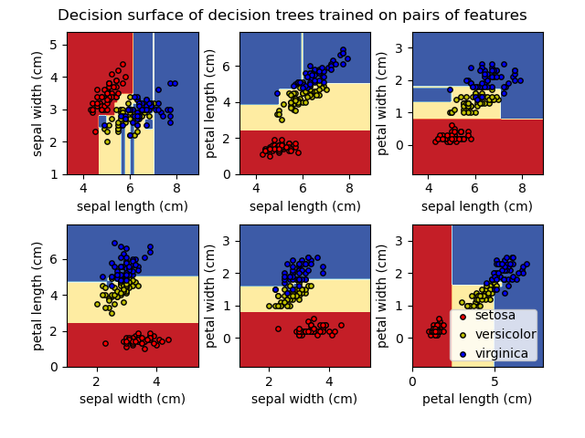

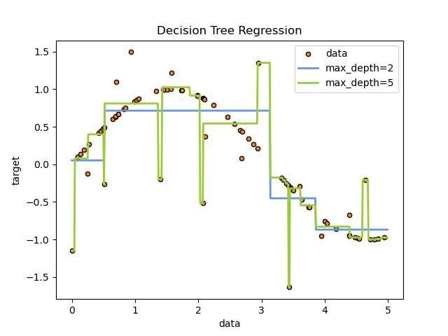

Set the model, engine, and *mode* (since a decision tree can do regression or classification).

```r
# Set the model, engine, and mode.
roomba_model <- decision_tree() |>
  set_engine(engine = "rpart") |>
  set_mode("classification")
```

## Workflows

We’re going to introduce another concept to help with training and evaluating our models: **workflows**.

Workflows combine the following:

- Our Data
- Pre-processing/feature engineering (recipes)
- Our Model

Today, we’ll see how to create a workflow that simplifies the data pre-processing, model fitting, and prediction tasks.

A **workflow** is a tidymodels object that combines the instructions of a recipe and a model. We’ll start with a simple workflow that only includes our **formula** (which outlines the relationship between our outcome and explanatory variables) and our **model** - the decision tree we defined previously.

```r
# Create a workflow.
roomba_wf_01 <- workflow() |>
  add_formula(
    segment ~ CleaningAttitudes_1 + CleaningAttitudes_2 + CleaningAttitudes_3 +
      CleaningAttitudes_4 + CleaningAttitudes_5 + CleaningAttitudes_6 +
      CleaningAttitudes_7 + CleaningAttitudes_8 + CleaningAttitudes_9 +
      CleaningAttitudes_10 + CleaningAttitudes_11
  ) |>
  add_model(roomba_model)
```

```r
roomba_wf_01
```

```
## ══ Workflow ════════════════════════════════════════════════════════════════════
## Preprocessor: Formula
## Model: decision_tree()
##
## ── Preprocessor ────────────────────────────────────────────────────────────────
## segment ~ CleaningAttitudes_1 + CleaningAttitudes_2 + CleaningAttitudes_3 +
##     CleaningAttitudes_4 + CleaningAttitudes_5 + CleaningAttitudes_6 +
##     CleaningAttitudes_7 + CleaningAttitudes_8 + CleaningAttitudes_9 +
##     CleaningAttitudes_10 + CleaningAttitudes_11
##
## ── Model ───────────────────────────────────────────────────────────────────────
## Decision Tree Model Specification (classification)
##
## Computational engine: rpart
```

## Fit a Workflow

We can fit the workflow itself since it includes the formula and model instructions.

```r
# Fit a workflow.
wf_fit_01 <- fit(roomba_wf_01, data = training(roomba_split))

wf_fit_01
```

```
## ══ Workflow [trained] ══════════════════════════════════════════════════════════
## Preprocessor: Formula
## Model: decision_tree()
##
## ── Preprocessor ────────────────────────────────────────────────────────────────
## segment ~ CleaningAttitudes_1 + CleaningAttitudes_2 + CleaningAttitudes_3 +
##     CleaningAttitudes_4 + CleaningAttitudes_5 + CleaningAttitudes_6 +
##     CleaningAttitudes_7 + CleaningAttitudes_8 + CleaningAttitudes_9 +
##     CleaningAttitudes_10 + CleaningAttitudes_11
##
## ── Model ───────────────────────────────────────────────────────────────────────
## n= 248
##
## node), split, n, loss, yval, (yprob)
##       * denotes terminal node
##
## 1) root 248 77 considering (0.6895161 0.1209677 0.1895161) *
```

## Evaluate Predictive Fit

We can evaluate predictive fit using the fitted workflow. For classification, there are a lot of possible measures of predictive fit, but accuracy is a natural one to use.

```r
# Compute model accuracy.
wf_fit_01 |>
  predict(new_data = testing(roomba_split)) |>
  bind_cols(testing(roomba_split)) |>
  accuracy(truth = segment, estimate = .pred_class)
```

```
## # A tibble: 1 × 3
##   .metric  .estimator .estimate
##   <chr>    <chr>          <dbl>
## 1 accuracy multiclass     0.690
```

We can also compute a confusion matrix. What does this show us?

```r
# Compute a confusion matrix.
wf_fit_01 |>
  predict(new_data = testing(roomba_split)) |>
  bind_cols(testing(roomba_split)) |>
  conf_mat(truth = segment, estimate = .pred_class)
```

```
##              Truth
## Prediction    considering own shopping
##   considering          58  10       16
##   own                   0   0        0
##   shopping              0   0        0
```

## Feature Engineering

Let’s try to improve our predictions. What if we included some demographic predictors instead? We’ll still want to dummy code them. Let’s build a recipe that pre-processes our categorical variables.

```r
# Build a recipe.
roomba_recipe <- training(roomba_split) |>
  recipe(
    segment ~ D1Gender + D2HomeType + D3Neighborhood + D4MaritalStatus
  ) |>
  step_dummy(all_nominal(), -segment)
```

Note that we haven’t used `prep()` – that will now be handled in the workflow.

## Update, Fit, and Evaluate

To include a recipe in our workflow, we remove the previous `formula` and add the recipe. *Typically* we will just add a recipe to our workflow to begin with. We started with the `formula` for illustrative purposes.

```r
# Update the workflow.
roomba_wf_02 <- roomba_wf_01 |>
  remove_formula() |>
  add_recipe(roomba_recipe)

roomba_wf_02
```

```
## ══ Workflow ════════════════════════════════════════════════════════════════════
## Preprocessor: Recipe
## Model: decision_tree()
##
## ── Preprocessor ────────────────────────────────────────────────────────────────
## 1 Recipe Step
##
## • step_dummy()
##
## ── Model ───────────────────────────────────────────────────────────────────────
## Decision Tree Model Specification (classification)
##
## Computational engine: rpart
```

By fitting a workflow that includes a recipe, `prep()`, `bake()`, and `fit()` are all executed in one step.

```r
# Fit a second workflow.
wf_fit_02 <- fit(roomba_wf_02, data = training(roomba_split))

wf_fit_02
```

```
## ══ Workflow [trained] ══════════════════════════════════════════════════════════
## Preprocessor: Recipe
## Model: decision_tree()
##
## ── Preprocessor ────────────────────────────────────────────────────────────────
## 1 Recipe Step
##
## • step_dummy()
##
## ── Model ───────────────────────────────────────────────────────────────────────
## n= 248
##
## node), split, n, loss, yval, (yprob)
##       * denotes terminal node
##
## 1) root 248 77 considering (0.6895161 0.1209677 0.1895161) *
```

By predicting using a fitted workflow, it does `bake()` and `predict()` in one step.

```r
# Compute model accuracy.
wf_fit_02 |>
  predict(new_data = testing(roomba_split)) |>
  bind_cols(testing(roomba_split)) |>
  accuracy(truth = segment, estimate = .pred_class)
```

```
## # A tibble: 1 × 3
##   .metric  .estimator .estimate
##   <chr>    <chr>          <dbl>
## 1 accuracy multiclass     0.690
```

```r
# Compute a confusion matrix.
wf_fit_02 |>
  predict(new_data = testing(roomba_split)) |>
  bind_cols(testing(roomba_split)) |>
  conf_mat(truth = segment, estimate = .pred_class)
```

```
##              Truth
## Prediction    considering own shopping
##   considering          58  10       16
##   own                   0   0        0
##   shopping              0   0        0
```

## Predict using Cleaning Attitudes and Demographics

```r
# Build a new recipe.
roomba_recipe_full <- training(roomba_split) |>
  recipe(
    segment ~ D1Gender + D2HomeType + D3Neighborhood + D4MaritalStatus +
      CleaningAttitudes_1 + CleaningAttitudes_2 + CleaningAttitudes_3 +
      CleaningAttitudes_4 + CleaningAttitudes_5 + CleaningAttitudes_6 +
      CleaningAttitudes_7 + CleaningAttitudes_8 + CleaningAttitudes_9 +
      CleaningAttitudes_10 + CleaningAttitudes_11
  ) |>
  step_dummy(all_nominal(), -all_outcomes())
```

## Update the Workflow Again

Create a third workflow that includes our full model. Notice we are updating the recipe this time by using the `remove_recipe()` function.

```r
# Update the workflow.
roomba_wf_03 <- roomba_wf_02 |>
  remove_recipe() |>
  add_recipe(roomba_recipe_full)

roomba_wf_03
```

```
## ══ Workflow ════════════════════════════════════════════════════════════════════
## Preprocessor: Recipe
## Model: decision_tree()
##
## ── Preprocessor ────────────────────────────────────────────────────────────────
## 1 Recipe Step
##
## • step_dummy()
##
## ── Model ───────────────────────────────────────────────────────────────────────
## Decision Tree Model Specification (classification)
##
## Computational engine: rpart
```

## Fit the Workflow

```r
# Fit the full workflow.
wf_fit_03 <- fit(roomba_wf_03, data = training(roomba_split))

wf_fit_03
```

```
## ══ Workflow [trained] ══════════════════════════════════════════════════════════
## Preprocessor: Recipe
## Model: decision_tree()
##
## ── Preprocessor ────────────────────────────────────────────────────────────────
## 1 Recipe Step
##
## • step_dummy()
##
## ── Model ───────────────────────────────────────────────────────────────────────
## n= 248
##
## node), split, n, loss, yval, (yprob)
##       * denotes terminal node
##
##  1) root 248 77 considering (0.68951613 0.12096774 0.18951613)
##    2) CleaningAttitudes_10< 0.5 115 28 considering (0.75652174 0.10434783 0.13913043) *
##    3) CleaningAttitudes_10>=0.5 133 49 considering (0.63157895 0.13533835 0.23308271)
##      6) CleaningAttitudes_4< 0.5 63 20 considering (0.68253968 0.19047619 0.12698413) *
##      7) CleaningAttitudes_4>=0.5 70 29 considering (0.58571429 0.08571429 0.32857143)
##       14) D1Gender< 1.5 51 16 considering (0.68627451 0.05882353 0.25490196) *
##       15) D1Gender>=1.5 19  9 shopping (0.31578947 0.15789474 0.52631579) *
```

## Evaluate Predictions from the Full Model

```r
# Compute model accuracy.
wf_fit_03 |>
  predict(new_data = testing(roomba_split)) |>
  bind_cols(testing(roomba_split)) |>
  accuracy(truth = segment, estimate = .pred_class)
```

```
## # A tibble: 1 × 3
##   .metric  .estimator .estimate
##   <chr>    <chr>          <dbl>
## 1 accuracy multiclass     0.702
```

## Confusion Matrix for the Full Model

```r
# Compute a confusion matrix.
wf_fit_03 |>
  predict(new_data = testing(roomba_split)) |>
  bind_cols(testing(roomba_split)) |>
  conf_mat(truth = segment, estimate = .pred_class)
```

```
##              Truth
## Prediction    considering own shopping
##   considering          56   9       13
##   own                   0   0        0
##   shopping              2   1        3
```

## Notes on Growing (Training/Fitting) a Decision Tree

Workflows help with the fact that we’re iterating on a lot of models as we try different predictors and changes to feature engineering. One of the *new* aspects of our models that we’ll tweak are called *hyperparameters*. Think of these as model characteristics that determine how the model fits the data. For decision trees we have

- `tree_depth` maximum depth of the tree (default is 30)
- `min_n` minimum number of data points in a node to be split (default is 20)

We can specify model parameters when we define the model.

```r
# Specify the model, engine, and mode.
roomba_model <- decision_tree(min_n = 5) |>
  set_engine(engine = "rpart") |>
  set_mode("classification")

roomba_model
```

```
## Decision Tree Model Specification (classification)
##
## Main Arguments:
##   min_n = 5
##
## Computational engine: rpart
```

```r
# Update the workflow.
roomba_wf_03 <- roomba_wf_03 |>
  update_model(roomba_model)

roomba_wf_03
```

```
## ══ Workflow ════════════════════════════════════════════════════════════════════
## Preprocessor: Recipe
## Model: decision_tree()
##
## ── Preprocessor ────────────────────────────────────────────────────────────────
## 1 Recipe Step
##
## • step_dummy()
##
## ── Model ───────────────────────────────────────────────────────────────────────
## Decision Tree Model Specification (classification)
##
## Main Arguments:
##   min_n = 5
##
## Computational engine: rpart
```

```r
# Fit the workflow.
wf_fit_03 <- fit(roomba_wf_03, data = training(roomba_split))

wf_fit_03
```

```
## ══ Workflow [trained] ══════════════════════════════════════════════════════════
## Preprocessor: Recipe
## Model: decision_tree()
##
## ── Preprocessor ────────────────────────────────────────────────────────────────
## 1 Recipe Step
##
## • step_dummy()
##
## ── Model ───────────────────────────────────────────────────────────────────────
## n= 248
##
## node), split, n, loss, yval, (yprob)
##       * denotes terminal node
##
##   1) root 248 77 considering (0.68951613 0.12096774 0.18951613)
##     2) CleaningAttitudes_10< 0.5 115 28 considering (0.75652174 0.10434783 0.13913043)
##       4) CleaningAttitudes_9>=0.5 39  3 considering (0.92307692 0.00000000 0.07692308) *
##       5) CleaningAttitudes_9< 0.5 76 25 considering (0.67105263 0.15789474 0.17105263)
##        10) D3Neighborhood< 1.5 13  2 considering (0.84615385 0.07692308 0.07692308) *
##        11) D3Neighborhood>=1.5 63 23 considering (0.63492063 0.17460317 0.19047619)
##          22) CleaningAttitudes_8< 0.5 43 13 considering (0.69767442 0.18604651 0.11627907) *
##          23) CleaningAttitudes_8>=0.5 20 10 considering (0.50000000 0.15000000 0.35000000)
##            46) D2HomeType>=1.5 7  2 considering (0.71428571 0.28571429 0.00000000)
##              92) CleaningAttitudes_3< 0.5 5  0 considering (1.00000000 0.00000000 0.00000000) *
##              93) CleaningAttitudes_3>=0.5 2  0 own (0.00000000 1.00000000 0.00000000) *
##            47) D2HomeType< 1.5 13  6 shopping (0.38461538 0.07692308 0.53846154)
##              94) CleaningAttitudes_1< 0.5 2  1 considering (0.50000000 0.50000000 0.00000000) *
##              95) CleaningAttitudes_1>=0.5 11  4 shopping (0.36363636 0.00000000 0.63636364)
##               190) CleaningAttitudes_6< 0.5 3  1 considering (0.66666667 0.00000000 0.33333333) *
##               191) CleaningAttitudes_6>=0.5 8  2 shopping (0.25000000 0.00000000 0.75000000) *
##     3) CleaningAttitudes_10>=0.5 133 49 considering (0.63157895 0.13533835 0.23308271)
##       6) CleaningAttitudes_4< 0.5 63 20 considering (0.68253968 0.19047619 0.12698413)
##        12) CleaningAttitudes_11< 0.5 61 18 considering (0.70491803 0.19672131 0.09836066)
##          24) CleaningAttitudes_9< 0.5 57 15 considering (0.73684211 0.17543860 0.08771930)
##            48) D2HomeType< 3.5 54 13 considering (0.75925926 0.14814815 0.09259259)
##              96) D3Neighborhood< 2.5 41  7 considering (0.82926829 0.09756098 0.07317073) *
##              97) D3Neighborhood>=2.5 13  6 considering (0.53846154 0.30769231 0.15384615)
##               194) CleaningAttitudes_8< 0.5 6  1 considering (0.83333333 0.00000000 0.16666667) *
##               195) CleaningAttitudes_8>=0.5 7  3 own (0.28571429 0.57142857 0.14285714) *
```

[output cut: 8 more lines]

```
##             116) D3Neighborhood>=1.5 27  7 considering (0.74074074 0.03703704 0.22222222) *
##             117) D3Neighborhood< 1.5 7  4 considering (0.42857143 0.28571429 0.28571429)
##               234) D4MaritalStatus< 3 5  2 considering (0.60000000 0.40000000 0.00000000) *
##               235) D4MaritalStatus>=3 2  0 shopping (0.00000000 0.00000000 1.00000000) *
##            59) CleaningAttitudes_6< 0.5 9  4 shopping (0.44444444 0.00000000 0.55555556)
##             118) CleaningAttitudes_8>=0.5 2  0 considering (1.00000000 0.00000000 0.00000000) *
##             119) CleaningAttitudes_8< 0.5 7  2 shopping (0.28571429 0.00000000 0.71428571) *
##        15) D1Gender>=1.5 19  9 shopping (0.31578947 0.15789474 0.52631579)
##          30) CleaningAttitudes_6< 0.5 6  2 considering (0.66666667 0.16666667 0.16666667) *
##          31) CleaningAttitudes_6>=0.5 13  4 shopping (0.15384615 0.15384615 0.69230769)
##            62) CleaningAttitudes_5< 0.5 2  0 considering (1.00000000 0.00000000 0.00000000) *
##            63) CleaningAttitudes_5>=0.5 11  2 shopping (0.00000000 0.18181818 0.81818182)
##
## ...
## and 2 more lines.
```

```r
# Compute model accuracy.
wf_fit_03 |>
  predict(new_data = testing(roomba_split)) |>
  bind_cols(testing(roomba_split)) |>
  accuracy(truth = segment, estimate = .pred_class)
```

```
## # A tibble: 1 × 3
##   .metric  .estimator .estimate
##   <chr>    <chr>          <dbl>
## 1 accuracy multiclass     0.631
```

```r
# Compute a confusion matrix.
wf_fit_03 |>
  predict(new_data = testing(roomba_split)) |>
  bind_cols(testing(roomba_split)) |>
  conf_mat(truth = segment, estimate = .pred_class)
```

```
##              Truth
## Prediction    considering own shopping
##   considering          52  10       13
##   own                   0   0        2
##   shopping              6   0        1
```

## Wrapping Up

*Summary*

- Demonstrated splitting data by strata.
- Discussed decision trees.
- Walked through building, using, and updating workflows.
- Tried a *little* hyperparameter tuning.

*Next Time*

- Why have one decision tree when you can have a forest?

*Supplementary Material*

- *Tidy Modeling with R* Chapter 7

*Artwork by @allison_horst*

## Exercise 12

We’ll be using the roomba survey data for this exercise. Roomba has asked us to train a model to classify customers into two segments, one that combines `own` and `shopping`, and one for `considering`. Your task is to compare the performance of logistic regression and a decision tree to find the best model for the client.

1. Use `case_when()` to combine the `own` and `shopping` segments into a single category.
2. Use workflows to combine the cleaning attitudes and demographics we’ve used in class and fit both a logistic regression and a decision tree. Which one has better predictive fit?
3. Try and tune the decision tree hyperparameters to improve its predictive fit.
4. Render the Quarto document into Word and upload to Canvas.